# Assignment 3

Dylan Culp

9/29/2020

```r
library(sf)
library(tidyverse)
library(ggthemes)
library(ggspatial)
library(units)
library(nngeo)
```

My four datasets are from Chicago. The first two are from the CTA open data site (https://www.transitchicago.com/data/) and the second two are from the city of Chicago’s Open Data portal (https://data.cityofchicago.org/)

A. CTA bus stops (point) B. CTA “L” Stations (point) C. Community Areas (polygon) D. Central Business District (polygon)

I will bring each dataset into R:

```r
bus_stops <- st_read("https://data.cityofchicago.org/download/84eu-buny/text%2Fxml", quiet=TRUE)
l_stops <- st_read("https://data.cityofchicago.org/download/4qtv-9w43/application%2Fxml", quiet=TRUE)
comm_areas <- st_read("https://data.cityofchicago.org/api/geospatial/cauq-8yn6?method=export&format=GeoJSON", quiet=TRUE)
cbd <- st_read("https://data.cityofchicago.org/api/geospatial/tksj-nvsw?method=export&format=GeoJSON", quiet=TRUE)
```

I will then transform the coordinates for each dataset to a Chicago PROJ4 string:

```r
chicago_coordinates <- "+proj=tmerc +lat_0=36.66666666666666 +lon_0=-88.33333333333333 +k=0.9999749999999999 +x_0=300000 +y_0=0 +ellps=GRS80 +units=m +no_defs"

bus_stops <- bus_stops %>%
  st_transform(chicago_coordinates)

l_stops <- l_stops %>%
  st_transform(chicago_coordinates)

comm_areas <- comm_areas %>%
  st_transform(chicago_coordinates)

cbd <- cbd %>%
  st_transform(chicago_coordinates)
```

1. How many L stops are in each community area?

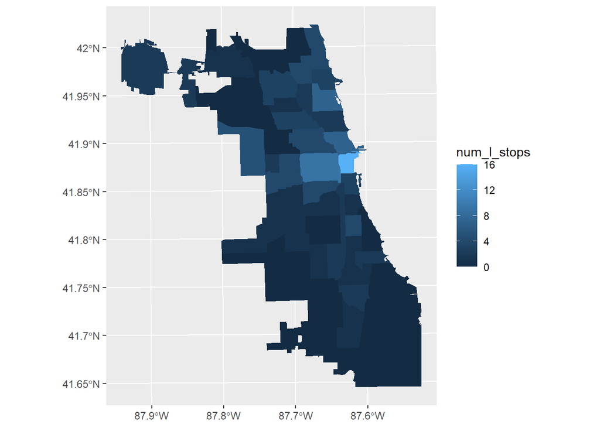

```r
comm_areas <- comm_areas %>%
  mutate(num_l_stops = lengths(st_covers(comm_areas, l_stops)))

ggplot(comm_areas)+
  geom_sf(color = NA,
  aes(fill = num_l_stops))
```

2. How many bus stops are in each community area?

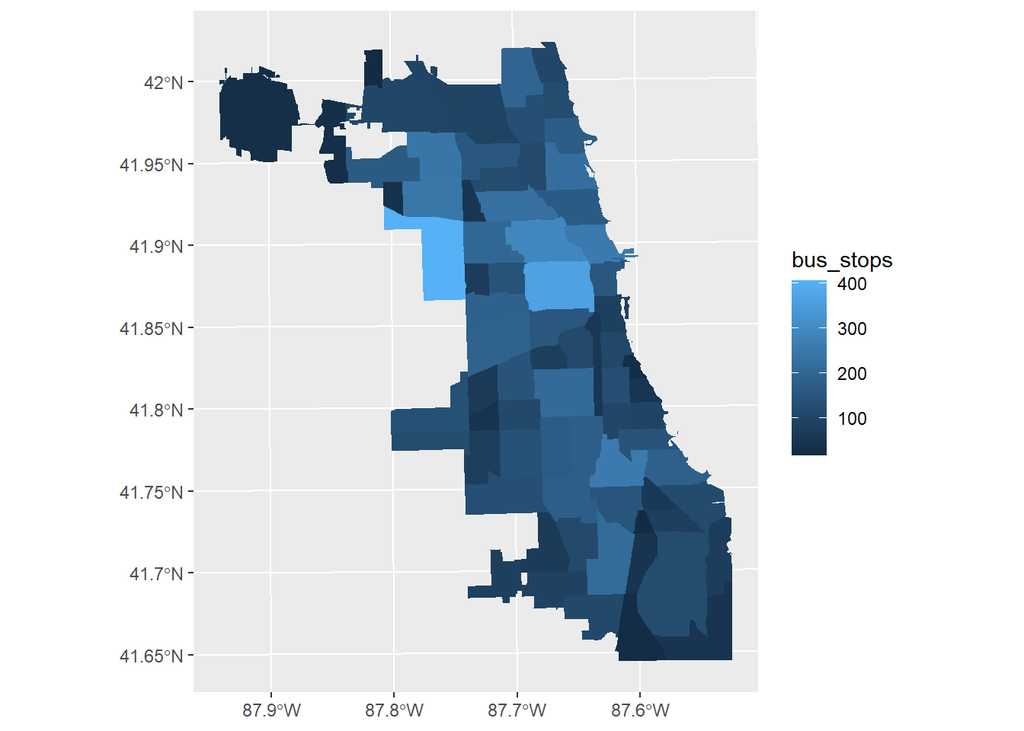

```r
comm_areas <- comm_areas %>%
  mutate(bus_stops = lengths(st_covers(comm_areas, bus_stops)))

ggplot(comm_areas)+
  geom_sf(color = NA,
  aes(fill = bus_stops))
```

3. What is the average distance between an L stop and nearest bus stop?

```r
l_stops <- l_stops %>%
  mutate(bus_dist = st_nn(l_stops, bus_stops,
                          returnDist = TRUE)$dist) %>%
    mutate(bus_dist = as.numeric(bus_dist))
```

```
## projected points
```

```r
  avg_bus_dist <- mean(l_stops$bus_dist)
  avg_bus_dist
```

```
## [1] 151.2962
```

Now for a map:

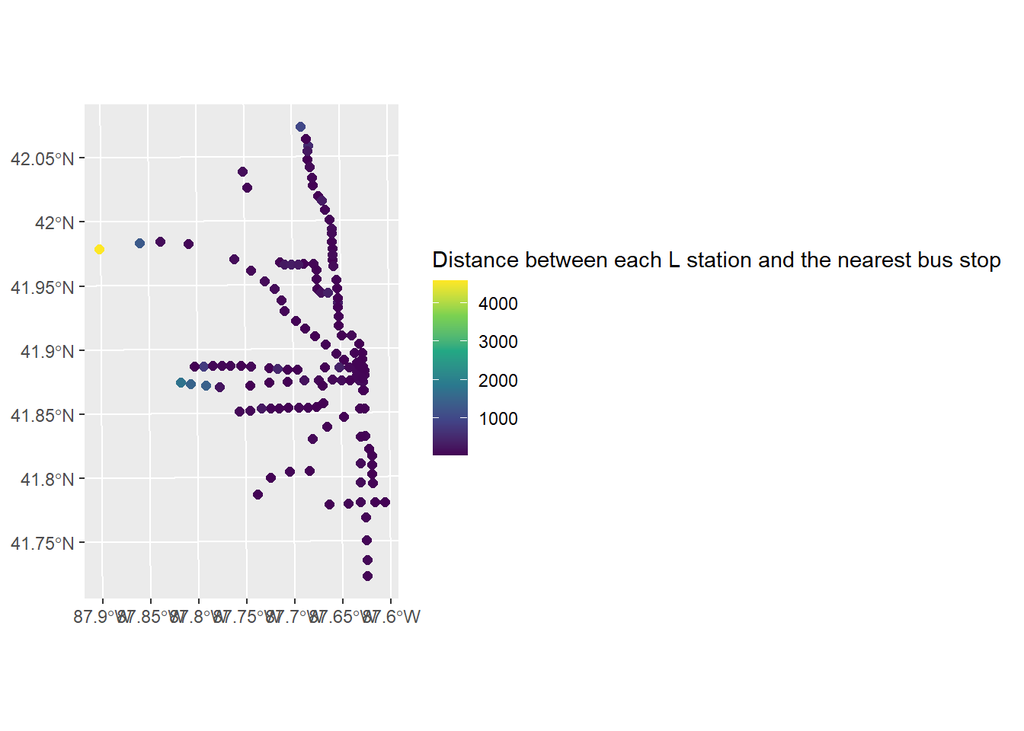

```r
ggplot(bus_stops)+
  geom_sf(data = l_stops, size = 2,
          aes(color = bus_dist))+
           scale_color_viridis_c(name = "Distance between each L station and the nearest bus stop")
```

Just about every L station is very close to a bus stop. This makes sense, as the bus network is presumably designed to feed riders to the rail system. I believe the one outlier that is very far from a local bus stop (yellow dot to the left) is O’Hare Airport.

4. What is the average distance between each bus stop and the nearest L station?

```r
bus_stops <- bus_stops %>%
  mutate(l_dist = st_nn(bus_stops, l_stops,
                          returnDist = TRUE)$dist) %>%
    mutate(l_dist = as.numeric(l_dist))
```

```
## projected points
```

```r
  avg_l_dist <- mean(bus_stops$l_dist)
  avg_l_dist
```

```
## [1] 1821.827
```

Unsurprisingly, the figure is significantly higher for bus stops, since buses fill in the gaps in areas without rail service.

Map:

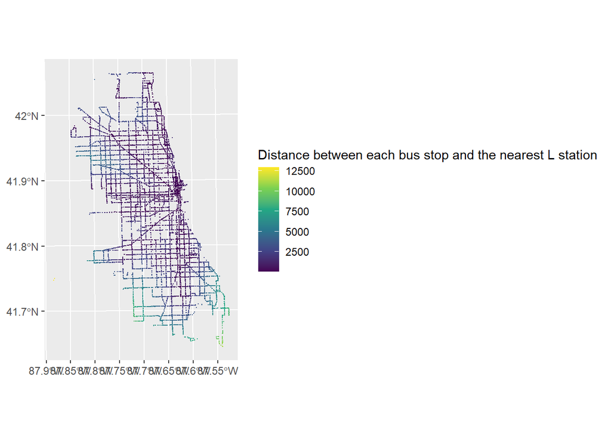

```r
ggplot(l_stops) +
  geom_sf(data = bus_stops, size = 0.1,
          aes(color=l_dist))+
  scale_color_viridis_c(name = "Distance between each bus stop and the nearest L station")
```

5. How many neighborhoods does the CBD overlap with?

```r
comm_areas <- comm_areas %>%
  mutate(num_cbd = lengths(st_overlaps(comm_areas, cbd))) %>%
  mutate(is_cbd = num_cbd >0)

number_cbd_overlap <- sum(comm_areas$is_cbd)
number_cbd_overlap
```

```
## [1] 5
```

Chicago’s CBD overlaps with 5 neighborhoods.

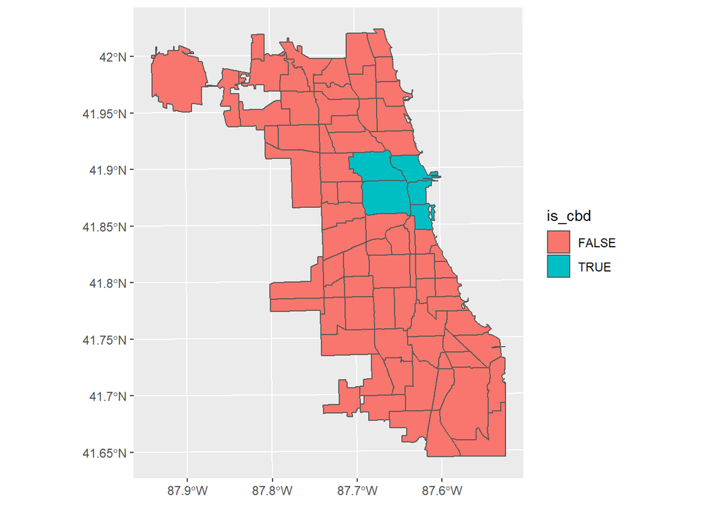

```r
ggplot()+
  geom_sf(fill="lightblue", color=NA)+
  geom_sf(data=comm_areas,
          aes(fill=is_cbd))
```

6. What is the density of L stations per square km, by community area?

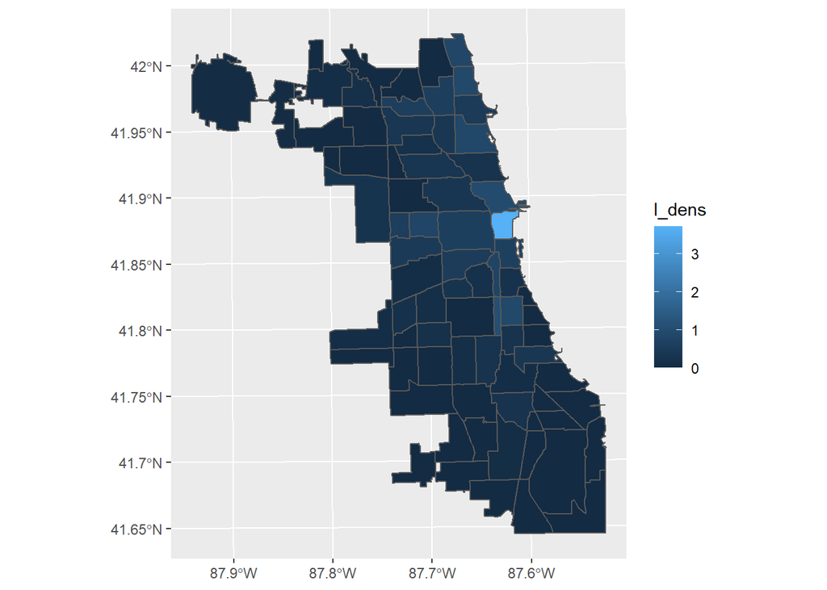

```r
comm_areas <- comm_areas %>%
  mutate(area=set_units(st_area(comm_areas), km^2)) %>%
  mutate(l_dens = as.numeric(num_l_stops / area))


ggplot(comm_areas)+
  geom_sf(data= comm_areas,
          aes(fill = l_dens))+
 scale_color_viridis_c(name = "L stations per square kilometer")
```